# 6372_Project_1

Bui, Andy

2026-09-22

```
##   age    sex    bmi children smoker    region   charges
## 1  19 female 27.900        0    yes southwest 16884.924
## 2  18   male 33.770        1     no southeast  1725.552
## 3  28   male 33.000        3     no southeast  4449.462
## 4  33   male 22.705        0     no northwest 21984.471
## 5  32   male 28.880        0     no northwest  3866.855
## 6  31 female 25.740        0     no southeast  3756.622
```

```
## 'data.frame':    1338 obs. of  7 variables:
##  $ age     : int  19 18 28 33 32 31 46 37 37 60 ...
##  $ sex     : chr  "female" "male" "male" "male" ...
##  $ bmi     : num  27.9 33.8 33 22.7 28.9 ...
##  $ children: int  0 1 3 0 0 0 1 3 2 0 ...
##  $ smoker  : chr  "yes" "no" "no" "no" ...
##  $ region  : chr  "southwest" "southeast" "southeast" "northwest" ...
##  $ charges : num  16885 1726 4449 21984 3867 ...
```

```
## [1] 1338    7
```

```
##       age               sex            bmi           children
##  Min.   :18.00   Length   :1338   Min.   :15.96   Min.   :0.000
##  1st Qu.:27.00   N.unique :   2   1st Qu.:26.30   1st Qu.:0.000
##  Median :39.00   N.blank  :   0   Median :30.40   Median :1.000
##  Mean   :39.21   Min.nchar:   4   Mean   :30.66   Mean   :1.095
##  3rd Qu.:51.00   Max.nchar:   6   3rd Qu.:34.69   3rd Qu.:2.000
##  Max.   :64.00                    Max.   :53.13   Max.   :5.000
##        smoker           region        charges
##  Length   :1338   Length   :1338   Min.   : 1122
##  N.unique :   2   N.unique :   4   1st Qu.: 4740
##  N.blank  :   0   N.blank  :   0   Median : 9382
##  Min.nchar:   2   Min.nchar:   9   Mean   :13270
##  Max.nchar:   3   Max.nchar:   9   3rd Qu.:16640
##                                    Max.   :63770
```

```
##       age            sex           bmi           children     smoker
##  Min.   :18.00   female:662   Min.   :15.96   Min.   :0.000   no :1064
##  1st Qu.:27.00   male  :676   1st Qu.:26.30   1st Qu.:0.000   yes: 274
##  Median :39.00                Median :30.40   Median :1.000
##  Mean   :39.21                Mean   :30.66   Mean   :1.095
##  3rd Qu.:51.00                3rd Qu.:34.69   3rd Qu.:2.000
##  Max.   :64.00                Max.   :53.13   Max.   :5.000
##        region       charges
##  northeast:324   Min.   : 1122
##  northwest:325   1st Qu.: 4740
##  southeast:364   Median : 9382
##  southwest:325   Mean   :13270
##                  3rd Qu.:16640
##                  Max.   :63770
```

```
##      age      sex      bmi children   smoker   region  charges
##        0        0        0        0        0        0        0
```

```
## [1] 1
```

```
##     age  sex   bmi children smoker    region  charges
## 582  19 male 30.59        0     no northwest 1639.563
```

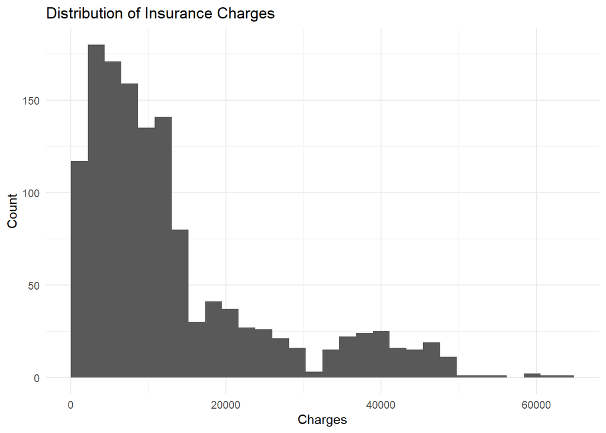

```
##   mean_age   sd_age mean_bmi   sd_bmi mean_children sd_children mean_charges
## 1 39.20703 14.04996  30.6634 6.098187      1.094918    1.205493     13270.42
##   sd_charges
## 1   12110.01
```

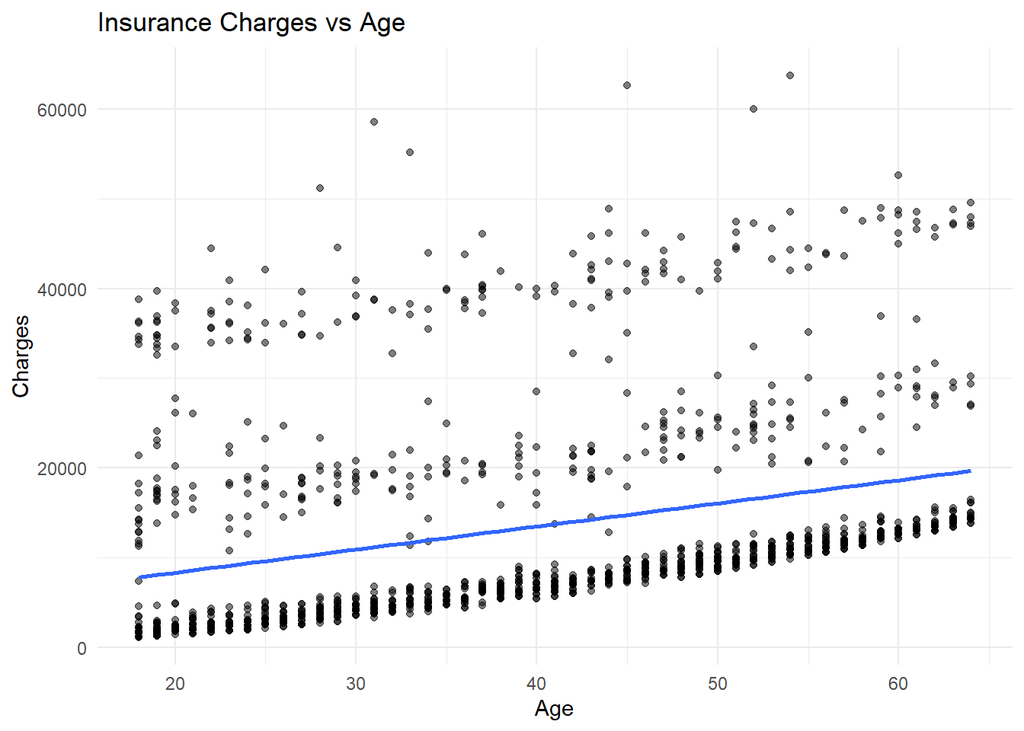

Positive relationship. Older customers tend to have higher chargers. Seem to be three different bands of chargers

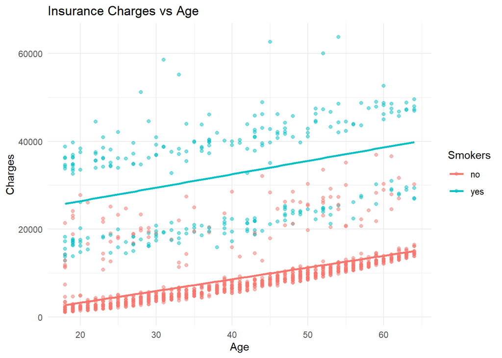

Smokers make up most of the 2 upper bands. Non smokers make up the lower band. Both slopes seem to be similar though

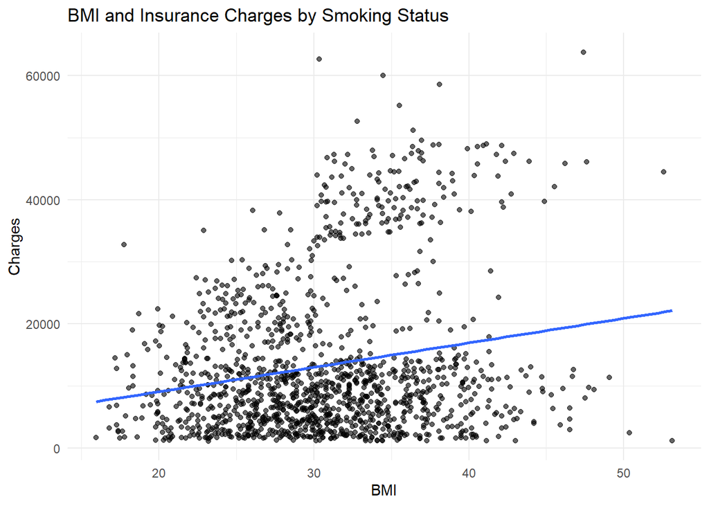

Another positive relationship as BMI increase charges increase.

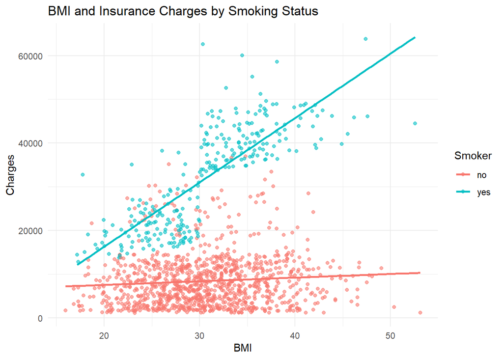

Separating the data we can see that there are 2 different slopes when it comes to BMI. One for smoke and one a smaller one for non

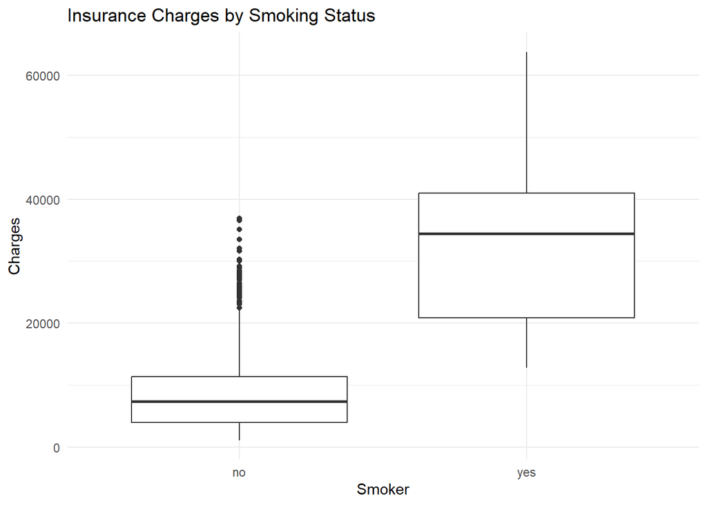

Smokers appear to have strong association with higher chargers while non smokers have an association with lower chargers. With this plot and the previous BMI plot, smoking is something we will want to look into for our model.

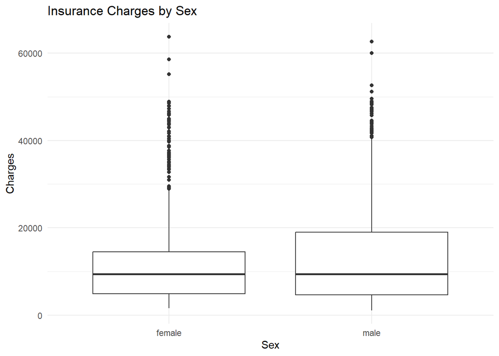

The median is practically identical for female and male. The spread of charges is slightly greater for males

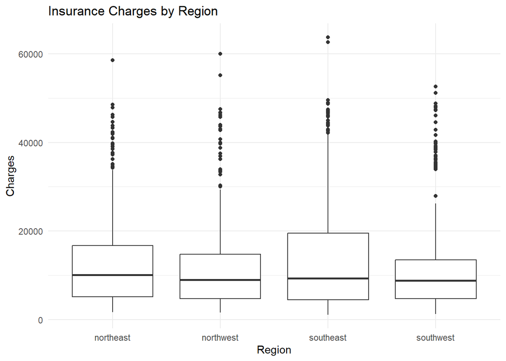

Insurance charges appear fairly similar across regions in terms of median values. The southeast shows greater variability and somewhat higher charges in the upper portion of the distribution

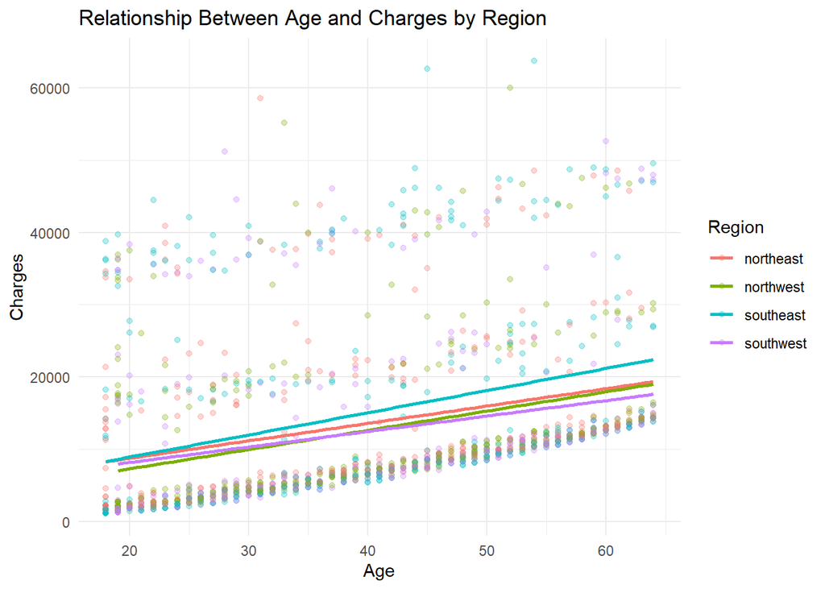

There is a positive association between age and charges across all regions. Similar slopes suggest little evidence that the age and charges relationship changes by region The fitted regression lines are relatively parallel, suggesting that the relationship between age and charges is fairly consistent across regions

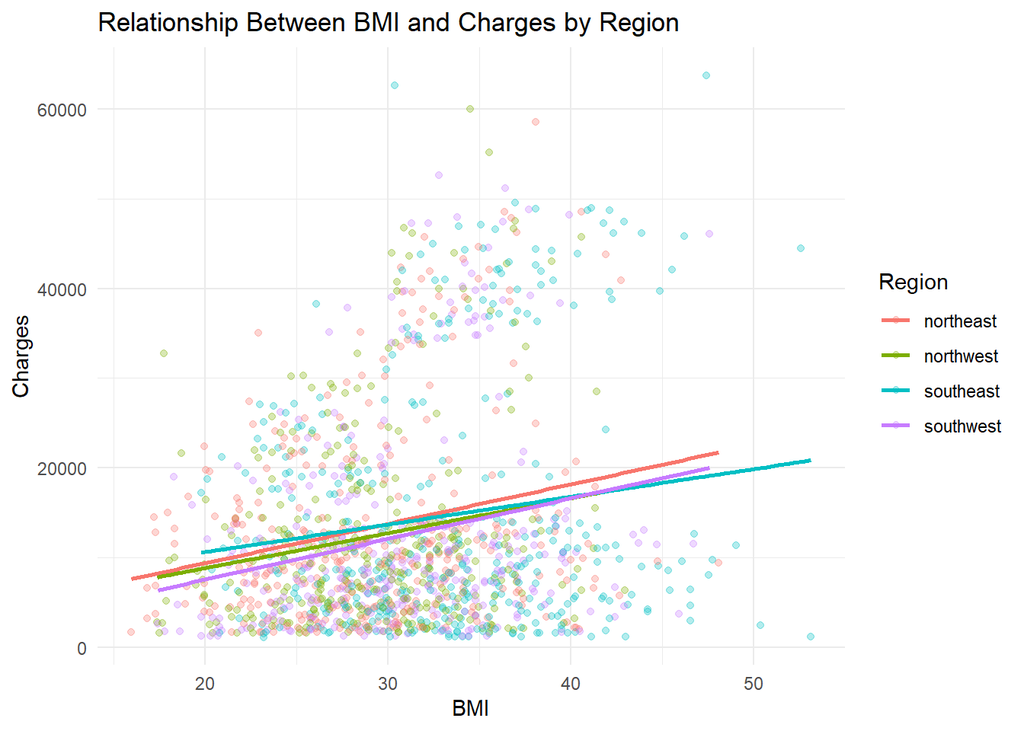

Similar to what is seen above. Similar slopes suggest little evidence that the BMI and charges relationship changes by region

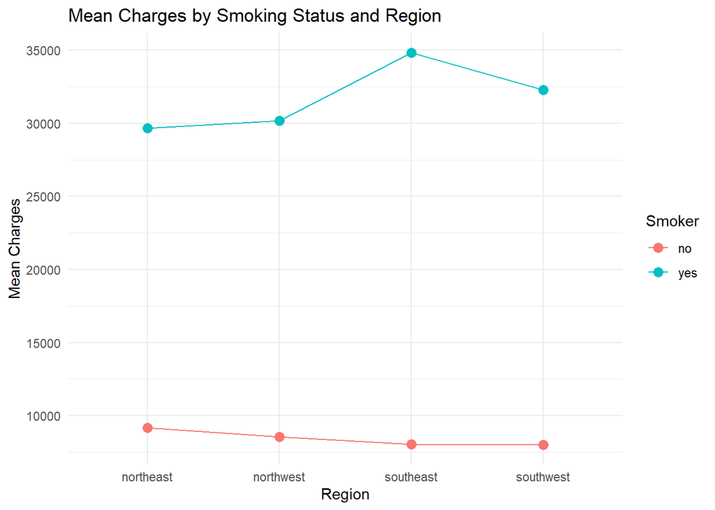

Non smokers mean charges are roughly similar across regions, while for smokers, mean charges vary much more by region, especially in the southeast, where the mean is noticeably higher, suggesting a possible interaction between smoking status and region.

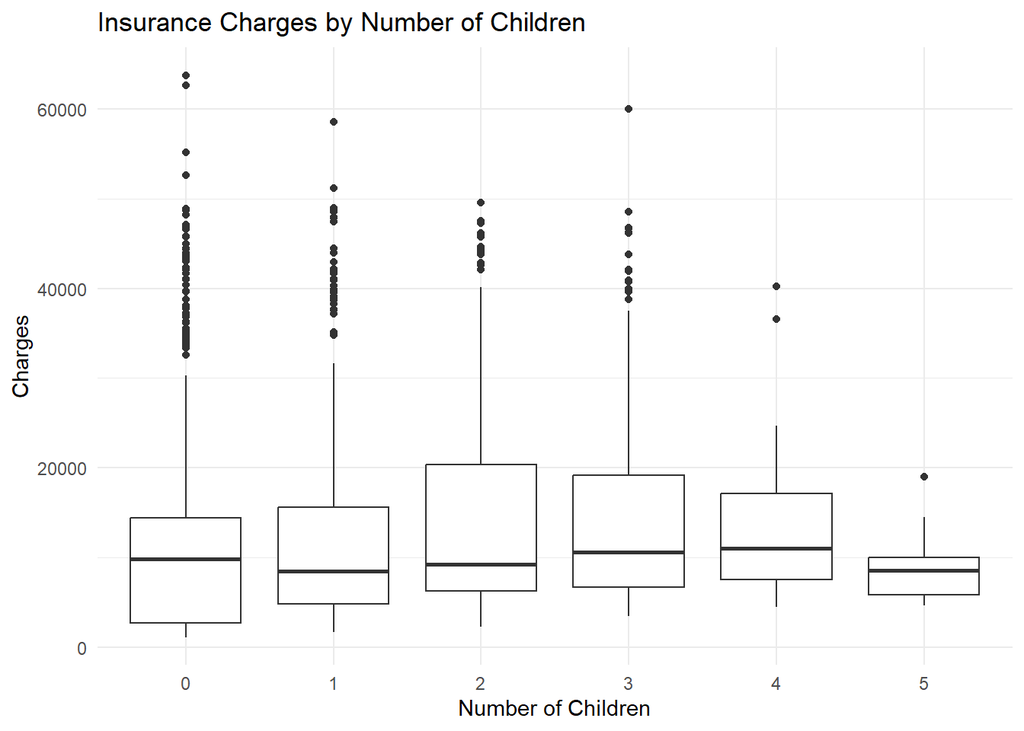

Insurance charges do not appear to change substantially with the number of children. Although customers with 3 or 4 children show slightly higher median charges, there is no clear trend across the groups.